# exploratory_Alex

alex

11/29/2017

```r
library(ggplot2)
library(dplyr)
library(tidyverse)
library(ggthemes)
library(gridExtra)
load(file = "finalLE.rda")
load(file = "AllMortality.rda")
load(file = "Predictors_1.rda")
```

## Life Expectancy Decline

In order to get a better understanding of where the most serious decline in life expectancy from 2010 to 2014 is happening in the U.S., we used the below code to generate the list of counties with the largest decrease in life expectancy.

```r
#Order of counties with the largest decreased LE (from 2010 - 2014)
ind <- order(ledata$change)
ledata$county[ind]
```

```
##    [1] Calumet County                    Bristol City
##    [3] Breathitt County                  Lee County
##    [5] Owsley County                     Lee County
##    [7] Leslie County                     Walker County
##    [9] Union County                      Estill County
##   [11] Hardin County                     Scott County
##   [13] Grenada County                    Anderson County
##   [15] Okfuskee County                   Kiowa County
##   [17] Claiborne County                  Powell County
##   [19] Whitley County                    Citrus County
##   [21] Wolfe County                      East Feliciana Parish
##   [23] Jefferson County                  Cocke County
##   [25] Benton County                     Poinsett County
##   [27] Glascock County                   Panola County
##   [29] Wayne County                      Beckham County
```

[output cut: 1583 more lines]

```r
ledata$change[ind]
```

```
##    [1] -0.76 -0.73 -0.66 -0.65 -0.65 -0.64 -0.56 -0.55 -0.55 -0.54 -0.53
##   [12] -0.53 -0.52 -0.51 -0.51 -0.49 -0.49 -0.48 -0.48 -0.47 -0.47 -0.47
##   [23] -0.46 -0.46 -0.46 -0.44 -0.44 -0.44 -0.43 -0.43 -0.43 -0.43 -0.43
##   [34] -0.43 -0.42 -0.42 -0.42 -0.42 -0.42 -0.42 -0.42 -0.41 -0.41 -0.41
##   [45] -0.40 -0.40 -0.40 -0.40 -0.40 -0.40 -0.40 -0.40 -0.39 -0.39 -0.39
##   [56] -0.39 -0.38 -0.38 -0.38 -0.38 -0.38 -0.37 -0.37 -0.37 -0.37 -0.37
##   [67] -0.37 -0.37 -0.37 -0.36 -0.36 -0.36 -0.36 -0.36 -0.36 -0.35 -0.35
##   [78] -0.35 -0.35 -0.34 -0.34 -0.34 -0.34 -0.34 -0.34 -0.34 -0.34 -0.33
##   [89] -0.33 -0.33 -0.33 -0.33 -0.33 -0.33 -0.33 -0.33 -0.33 -0.32 -0.32
##  [100] -0.32 -0.32 -0.32 -0.32 -0.32 -0.32 -0.32 -0.32 -0.31 -0.31 -0.31
##  [111] -0.31 -0.31 -0.31 -0.31 -0.30 -0.30 -0.30 -0.30 -0.30 -0.30 -0.30
##  [122] -0.30 -0.29 -0.29 -0.29 -0.29 -0.29 -0.29 -0.29 -0.29 -0.29 -0.29
##  [133] -0.29 -0.29 -0.29 -0.28 -0.28 -0.28 -0.28 -0.28 -0.28 -0.28 -0.28
##  [144] -0.28 -0.28 -0.28 -0.28 -0.28 -0.28 -0.28 -0.28 -0.28 -0.28 -0.28
##  [155] -0.28 -0.28 -0.28 -0.28 -0.28 -0.27 -0.27 -0.27 -0.27 -0.27 -0.27
```

[output cut: 276 more lines]

While the above exploratory analysis is interesting, we decided that it would be more interesting to look at the states as a whole. There could be large outliers within each state with life expectancy and we didn’t want our data to be skewed by such outliers. So, we asked the question, “which state had the largest decline in life expectancy during this same time period?”"

```r
#Create dataframe with only state avg
lestate <- ledata[!grepl("County", ledata$county),]
lestate <- lestate[!grepl("Area", lestate$county),]
lestate <- lestate[!grepl("Municipality", lestate$county),]
lestate <- lestate[!grepl("Borough", lestate$county),]
lestate <- lestate[!grepl("Parish", lestate$county),]
lestate <- lestate[!grepl("City", lestate$county),]
```

```r
#Order of states with the largest decreased LE (from 2010 - 2014)
ind <- order(lestate$change)
lestate$state[ind]
```

```
##  [1] Mississippi           West Virginia         Kentucky
##  [4] Oklahoma              Utah                  Arkansas
##  [7] Indiana               Hawaii                New Mexico
## [10] Tennessee             Kansas                New Hampshire
## [13] Nebraska              Iowa                  Ohio
## [16] Louisiana             Alabama               Michigan
## [19] Idaho                 Connecticut           North Dakota
## [22] Missouri              Wyoming               Oregon
## [25] Illinois              Wisconsin             Maine
## [28] Alaska                Massachusetts         Montana
## [31] Pennsylvania          Washington            Rhode Island
## [34] Colorado              Minnesota             North Carolina
## [37] South Dakota          Texas                 South Carolina
## [40] United States         Arizona               Vermont
## [43] Georgia               Virginia              New Jersey
## [46] Maryland              Nevada                New York
## [49] Delaware              Florida               California
## [52] District of Columbia   District of Columbia
## 103 Levels:  Alabama  Alaska  Arizona  Arkansas  California ... Wyoming
```

```r
lestate$change[ind]
```

```
##  [1] -0.04 -0.04 -0.03 -0.03 -0.03 -0.03 -0.01 -0.01  0.01  0.01  0.02
## [12]  0.03  0.04  0.06  0.06  0.07  0.07  0.08  0.09  0.10  0.10  0.11
## [23]  0.13  0.14  0.15  0.15  0.16  0.17  0.17  0.17  0.17  0.18  0.18
## [34]  0.19  0.20  0.20  0.21  0.22  0.23  0.26  0.28  0.28  0.30  0.30
## [45]  0.33  0.37  0.37  0.37  0.39  0.44  0.48  0.67  0.67
```

Going back to the county level, we wanted to check what the range of change in life expectancy was during this time period in each state. What percent of counties had a decline in life expectancy compared to an increase?

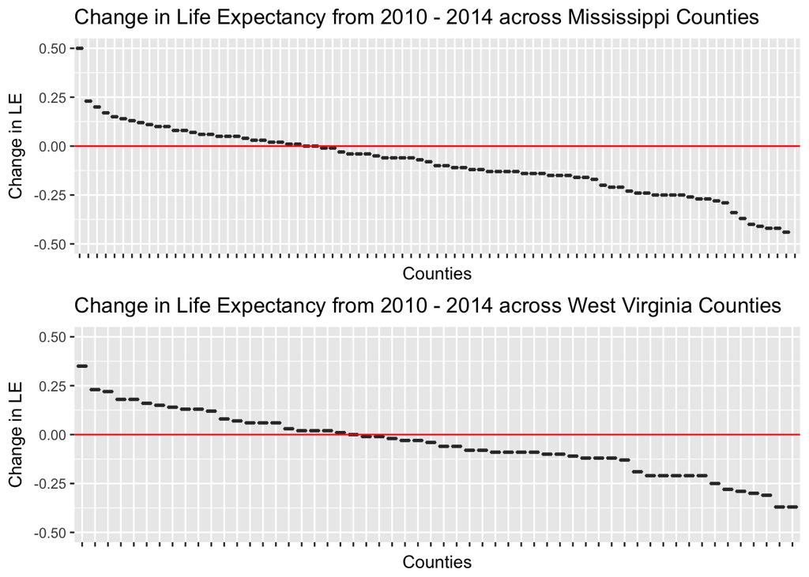

```r
# Graph of change in le (from 2010-2014) in each county in Mississippi and West Virginia
mle <- ledata %>% mutate(rn = row_number()) %>% filter(rn <= 1509, rn >= 1427)
wvle <- ledata %>% mutate(rn = row_number()) %>% filter(rn <= 3097, rn >= 3042)

P1 <- ggplot(data = mle, aes(x = reorder(county, -change), y = change)) +
  geom_boxplot() +
  geom_hline(yintercept = 0, col = "red") +
  theme(axis.text.x = element_text(angle = 90, hjust = 1)) +
  scale_y_continuous(limits = c(-0.5, 0.5)) +
  xlab("Counties") +
  ylab("Change in LE") +
  ggtitle("Change in Life Expectancy from 2010 - 2014 across Mississippi Counties") +
   theme(legend.position = "none",
        axis.text.x=element_blank())

G1 <- ggplot(data = wvle, aes(x = reorder(county, -change), y = change)) +
  geom_boxplot() +
  geom_hline(yintercept = 0, col = "red") +
  theme(axis.text.x = element_text(angle = 90, hjust = 1)) +
  scale_y_continuous(limits = c(-0.5, 0.5)) +
  ylab("Change in LE") +
  xlab("Counties") +
  ggtitle("Change in Life Expectancy from 2010 - 2014 across West Virginia Counties") +
  theme(legend.position = "none",
        axis.text.x=element_blank())
grid.arrange(P1, G1)
```

We can see from the graphs above that there were quite a few counties that had a decline in life expectancy. How many exactly were there?

```r
# How many counties had negative change in LE
sum(mle$change < 0) #55 out of 82 counties have negative changes in LE in Mississippi
```

```
## [1] 55
```

```r
sum(wvle$change <0) #34 out of 55 counties have negative changes in LE in West Virginia
```

```
## [1] 34
```

The above exploration caused us to want to look at the all cause mortality rates in these two states. We assume that with a decline in life expectancy that we would see an increase in cause mortality.

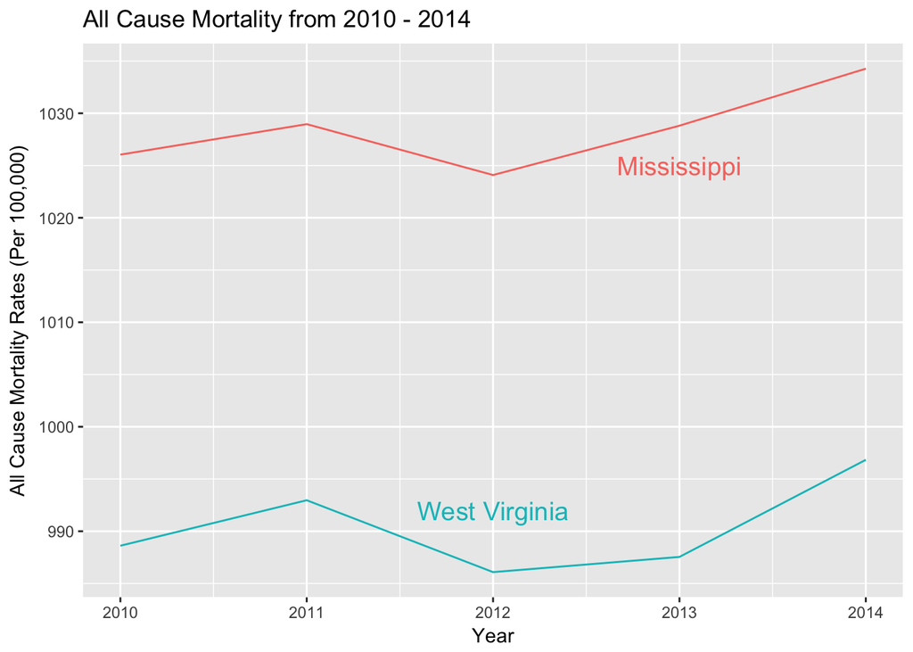

```r
# All Cause Mortality in Mississippii and West Virginia
States <- c("Mississippi", "West Virginia")
label <- data.frame(location_name = States, x = c(2013,2012), y = c(1025,992))
two <- AllMortality %>% filter(location_name %in% c("Mississippi", "West Virginia"))
two2 <- filter(two, cause_id == 294, sex_id == 3)
p1 <-  ggplot(data = two2, aes(year_id, mx, col = location_name))
p1 +  geom_line() +
   geom_text(data = label, aes(x, y, label = States), size = 5) +
  ggtitle("All Cause Mortality from 2010 - 2014") +
  ylab("All Cause Mortality Rates (Per 100,000)") +
  xlab("Year") +
   theme(legend.position = "none")
```

This graph above shows that both West Virginia and Mississippi saw an increase in all cause mortality rates, which corroborates our findings in our life expectancy decline exploration.

We did notice, however, that it is difficult to judge how these two states differ from the rest of the country. The y axis all cause mortality ranges from 980 - 1040, which is not a large gap contrary to what it looks like visually. We decided we needed a reference state to compare our two states to. We picked Hawaii, which had the largest life expectancy in 2014.

```r
# Code to find highest LE in 2014:
ind <- order(lestate$LE2014)
lestate$state[ind]
```

```
##  [1] Mississippi           Alabama               Louisiana
##  [4] West Virginia         Oklahoma              Arkansas
##  [7] Kentucky              Tennessee             District of Columbia
## [10]  District of Columbia South Carolina        Georgia
## [13] Indiana               Missouri              North Carolina
## [16] Ohio                  Nevada                Michigan
## [19] New Mexico            Alaska                Texas
## [22] Wyoming               Delaware              Kansas
## [25] Pennsylvania          Montana               Illinois
## [28] United States         Maryland              Virginia
## [31] Maine                 Oregon                Florida
## [34] Idaho                 South Dakota          Arizona
## [37] Nebraska              Iowa                  Rhode Island
## [40] Wisconsin             Utah                  North Dakota
## [43] Washington            New Jersey            New Hampshire
## [46] Colorado              Vermont               New York
## [49] Massachusetts         Connecticut           California
## [52] Minnesota             Hawaii
## 103 Levels:  Alabama  Alaska  Arizona  Arkansas  California ... Wyoming
```

```r
lestate$LE2014[ind]
```

```
##  [1] 74.91 75.65 75.82 76.03 76.09 76.18 76.26 76.33 76.86 76.86 76.89
## [12] 77.38 77.69 77.73 77.86 77.91 78.11 78.26 78.35 78.41 78.54 78.62
## [23] 78.72 78.74 78.76 78.93 79.02 79.08 79.16 79.18 79.32 79.44 79.48
## [34] 79.49 79.57 79.58 79.58 79.73 79.76 79.79 79.91 79.95 79.99 80.04
## [45] 80.15 80.21 80.24 80.36 80.41 80.56 80.82 80.90 81.15
```

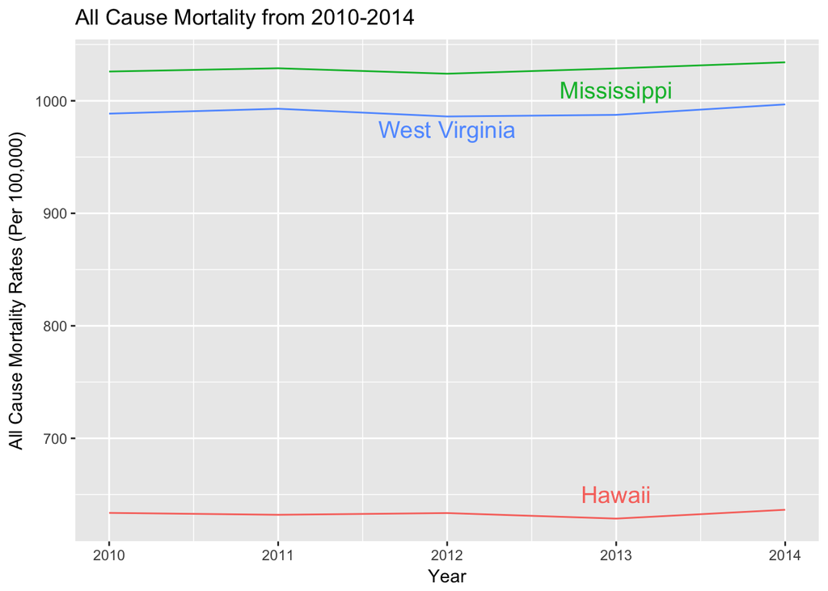

```r
# But how does that compare to the state that had the most improved LE from 2010 - 2014?
State <- c("Mississippi", "West Virginia", "Hawaii")
label <- data.frame(location_name = State, x = c(2013,2012, 2013), y = c(1010,975, 650))
three <- AllMortality %>% filter(location_name %in% c("Mississippi", "West Virginia", "Hawaii"))
three2 <- filter(three, cause_id == 294, sex_id == 3)
p1 <-  ggplot(data = three2, aes(year_id, mx, col = location_name))
p1 +  geom_line() +
   geom_text(data = label, aes(x, y, label = State), size = 5) +
  ggtitle("All Cause Mortality from 2010-2014") +
    ylab("All Cause Mortality Rates (Per 100,000)") +
  xlab("Year") +
   theme(legend.position = "none")
```

We can now see that West Virginia and Mississippi had very similar trends in all cause mortality rates and that Hawaii, the state with the highest life expectancy, had a much lower all cause mortality rates throughout the five years of data. It is important in these types of graphs to have a reference category to compare to in order not to draw false inferences.

Next, we wanted to see how life expectancy decline and the County Health Rankings (CHR) compared to each other. How did the county with the largest decrease in life expectancy fare in CHR?

```r
#How do the worst counties in each state for change in LE fair in the CHR ranking?

#Mississippi
ind <- order(mle$change)
mle$county[ind] #Grenada County, -0.52
```

```
##  [1] Grenada County         Panola County          Carroll County
##  [4] Neshoba County         Alcorn County          Webster County
##  [7] Tishomingo County      Leake County           Harrison County
## [10] Jones County           Benton County          Holmes County
## [13] Covington County       Claiborne County       Franklin County
## [16] Newton County          Tippah County          Yalobusha County
## [19] Itawamba County        Hinds County           Coahoma County
## [22] George County          Marshall County        Winston County
## [25] Pontotoc County        Yazoo County           Amite County
## [28] Jasper County          Tate County            Attala County
## [31] Jefferson Davis County Smith County           Calhoun County
## [34] Clarke County          Lee County             Lincoln County
## [37] Clay County            Tunica County          Lowndes County
## [40] Union County           Chickasaw County       Hancock County
## [43] Pike County            Jefferson County       Monroe County
## [46] Perry County           Humphreys County       Marion County
## [49] Wilkinson County       Mississippi            Montgomery County
## [52] Wayne County           Greene County          Lawrence County
## [55] Leflore County         Copiah County          Quitman County
## [58] Warren County          Stone County           Adams County
## [61] Walthall County        Prentiss County        Sunflower County
## [64] Washington County      Bolivar County         Tallahatchie County
## [67] Pearl River County     Choctaw County         Jackson County
## [70] Sharkey County         DeSoto County          Oktibbeha County
## [73] Kemper County          Noxubee County         Simpson County
## [76] Scott County           Madison County         Lafayette County
## [79] Issaquena County       Forrest County         Lauderdale County
## [82] Lamar County           Rankin County
## 1928 Levels:  Abbeville County Acadia Parish Accomack County ... Ziebach County
```

```r
mle$change[ind]
```

```
##  [1] -0.52 -0.44 -0.42 -0.42 -0.41 -0.40 -0.37 -0.34 -0.29 -0.28 -0.27
## [12] -0.27 -0.26 -0.25 -0.25 -0.25 -0.25 -0.24 -0.24 -0.23 -0.21 -0.21
## [23] -0.20 -0.17 -0.16 -0.16 -0.15 -0.15 -0.15 -0.14 -0.14 -0.14 -0.13
## [34] -0.13 -0.13 -0.13 -0.12 -0.12 -0.11 -0.11 -0.10 -0.10 -0.08 -0.07
## [45] -0.06 -0.06 -0.06 -0.06 -0.05 -0.04 -0.04 -0.04 -0.03 -0.01 -0.01
## [56]  0.00  0.00  0.01  0.01  0.02  0.02  0.03  0.03  0.04  0.05  0.05
## [67]  0.05  0.06  0.06  0.07  0.08  0.08  0.10  0.10  0.11  0.12  0.13
## [78]  0.14  0.15  0.17  0.20  0.23  0.50
```

```r
#West Virginia
ind <- order(wvle$change)
wvle$county[ind] #Logan County,
```

```
##  [1] Logan County      Mingo County      Cabell County
##  [4] Boone County      Wood County       Mercer County
##  [7] Wyoming County    Clay County       Hancock County
## [10] Berkeley County   Lewis County      Roane County
## [13] Wayne County      Barbour County    McDowell County
## [16] Webster County    Randolph County   Ritchie County
## [19] Lincoln County    Putnam County     Braxton County
## [22] Doddridge County  Fayette County    Upshur County
## [25] Nicholas County   Wirt County       Harrison County
## [28] Wetzel County     West Virginia     Jackson County
## [31] Pleasants County  Gilmer County     Marshall County
## [34] Preston County    Ohio County       Marion County
## [37] Mason County      Tyler County      Calhoun County
## [40] Monroe County     Grant County      Greenbrier County
## [43] Summers County    Pocahontas County Kanawha County
## [46] Morgan County     Pendleton County  Tucker County
## [49] Hardy County      Brooke County     Taylor County
## [52] Monongalia County Raleigh County    Hampshire County
## [55] Jefferson County  Mineral County
## 1928 Levels:  Abbeville County Acadia Parish Accomack County ... Ziebach County
```

```r
wvle$change[ind] #-0.37
```

```
##  [1] -0.37 -0.37 -0.31 -0.30 -0.29 -0.28 -0.25 -0.21 -0.21 -0.21 -0.21
## [12] -0.21 -0.19 -0.13 -0.12 -0.12 -0.12 -0.11 -0.10 -0.10 -0.09 -0.09
## [23] -0.09 -0.09 -0.08 -0.08 -0.06 -0.06 -0.04 -0.03 -0.03 -0.02 -0.01
## [34] -0.01  0.00  0.01  0.02  0.02  0.02  0.03  0.06  0.06  0.06  0.07
## [45]  0.08  0.12  0.13  0.13  0.14  0.15  0.16  0.18  0.18  0.22  0.23
## [56]  0.35
```

```r
#find rank
IV2 <- dplyr::filter(IV, State == c("West Virginia", "Mississippi"))
Grenada <- IV2 %>% filter(County == "Grenada")
Logan <- IV2 %>% filter(County == "Logan")
Logan # Logan ranked 49 in 2011 and 51 in 2015 out of 55
```

```
##    FIPS         State County year N_RankedCounties HO_rank HO_quart
## 1 54045 West Virginia  Logan 2011               55      52        4
## 2 54045 West Virginia  Logan 2013               NA      52       NA
## 3 54045 West Virginia  Logan 2015               55      52        4
##   HF_rank HF_quart MORT_rank MORT_quart MORB_rank MORB_quart HB_rank
## 1      49        4        53          4        52          4      53
## 2      52       NA        52         NA        51         NA      55
## 3      51        4        52          4        51          4      53
##   HB_quart CC_rank CC_quart SE_rank SE_quart PE_rank PE_quart Deaths
## 1        4      51        4      41        3      17        2    857
## 2       NA      53       NA      38       NA      21       NA    825
## 3        4      52        4      47        4      23        2    862
##   Population YPPL_rate Fair_percent PPH_days PMH_days LBW_percent
## 1      35525     14996           33      7.1      6.3        11.0
## 2      36457     12822           30      6.6      6.1        11.8
## 3      35987     14461           31      6.4      5.9        11.3
##   smoking_percent Obese_percent Binge_percent MV_rate CHL_100000
## 1              35            34            10      33        132
## 2              37            38            10      34         54
## 3              37            40            10      NA         91
##   TeenB_rate Uninsure_percent PCP_rate diab_rate unemploy_rate
## 1         59               17       73        15           8.3
## 2         62               20       63        15           8.4
## 3         66               18       61        15           8.9
##   Childpov_percent inactive_percent
## 1               32               NA
## 2               28               44
## 3               30               41
```

```r
Grenada # Grenada ranked 54 in 2013 and 51 in 2015 out of 82
```

```
##    FIPS       State  County year N_RankedCounties HO_rank HO_quart HF_rank
## 1 28043 Mississippi Grenada 2011               81      68        4      49
## 2 28043 Mississippi Grenada 2013               NA      54       NA      45
## 3 28043 Mississippi Grenada 2015               82      51        3      42
##   HF_quart MORT_rank MORT_quart MORB_rank MORB_quart HB_rank HB_quart
## 1        3        63          4        73          4      45        3
## 2       NA        51         NA        64         NA      74       NA
## 3        3        63          4        34          2      66        4
##   CC_rank CC_quart SE_rank SE_quart PE_rank PE_quart Deaths Population
## 1      28        2      61        3       9        1    389      22995
## 2      13       NA      47       NA       5       NA    383      21706
## 3      13        1      45        3      24        2    427      21612
##   YPPL_rate Fair_percent PPH_days PMH_days LBW_percent smoking_percent
## 1     12965           27      5.7      5.1        11.6              25
## 2     11771           29      4.8      4.6        12.1              29
## 3     12087           26      4.3      3.9        11.2              28
##   Obese_percent Binge_percent MV_rate CHL_100000 TeenB_rate
## 1            36            12      28        587         69
## 2            37            16      26        877         69
## 3            38            12      NA        821         66
##   Uninsure_percent PCP_rate diab_rate unemploy_rate Childpov_percent
## 1               20       61        13          12.6               30
## 2               21       50        14          11.2               31
## 3               19       46        15           9.2               36
##   inactive_percent
## 1               NA
## 2               36
## 3               32
```